# data.table package

by Craig W. Slinkman

September 3, 2015

Within the last year that has been an upgrade to the data.frame that is more efficient than a data.frame in programming time, processing time, and storage space. This new upgrade is called the data.table.

## Packages

A package is a grouped set of functionality that does not come with the base-R functionaility. To use a package we must functionality we must install the package on our version. Then before we use we must load the package into our R-environment.

To load the environment we use the following menu path

$Menu --> Tools --> Install Packages$

We then type $data.table$ in the package box and click OK.

to use the data.frame package we must either load the package with the $library$ function or load it with the $require$ function. I tend to use the $require$ function.

## Loading the $data.table$ package

```r
library( data.table )
```

Or we can use the $require$ function:

```r
require( data.table )
```

We will now read the $Flights.csv$ table in the data folder. We do this to save time so we do not get networks delay. The $data.table$ package gas a very fast read function called $fread$. We use the $fread$ as follows:

```r
require( data.table )

inFile <-
    file.path( getwd(),         # Specify path to file
               "data",
               "Flights.csv")


Flights <- fread( inFile )      # Read Flight.csv file

tables()                        # Display data about tables
```

```
##      NAME       NROW NCOL MB
## [1,] Flights 253,316   18 35
##      COLS
## [1,] V1,year,month,day,dep_time,dep_delay,arr_time,arr_delay,cancelled,carrier,tailnu
##      KEY
## [1,]
## Total: 35MB
```

```r
Flights                         # Display some content of Flights
```

```
##             V1 year month day dep_time dep_delay arr_time arr_delay
##      1:      1 2014     1   1      914        14     1238        13
##      2:      2 2014     1   1     1157        -3     1523        13
##      3:      3 2014     1   1     1902         2     2224         9
##      4:      4 2014     1   1      722        -8     1014       -26
##      5:      5 2014     1   1     1347         2     1706         1
##     ---
## 253312: 253312 2014    10  31     1459         1     1747       -30
## 253313: 253313 2014    10  31      854        -5     1147       -14
## 253314: 253314 2014    10  31     1102        -8     1311        16
## 253315: 253315 2014    10  31     1106        -4     1325        15
## 253316: 253316 2014    10  31      824        -5     1045         1
##         cancelled carrier tailnum flight origin dest air_time distance
##      1:         0      AA  N338AA      1    JFK  LAX      359     2475
##      2:         0      AA  N335AA      3    JFK  LAX      363     2475
```

[output cut: 21 more lines]

## $data.table$ subset selection

It is simpler assnd faster to do subset selction with a $data.table$ object.

```r
DFW <- Flights[dest=="DFW", ]
tables()
```

```
##      NAME       NROW NCOL MB
## [1,] DFW       6,487   18  1
## [2,] Flights 253,316   18 35
##      COLS
## [1,] V1,year,month,day,dep_time,dep_delay,arr_time,arr_delay,cancelled,carrier,tailnu
## [2,] V1,year,month,day,dep_time,dep_delay,arr_time,arr_delay,cancelled,carrier,tailnu
##      KEY
## [1,]
## [2,]
## Total: 36MB
```

## Computing statistics with $data.table$

We can compute statiustics with $data.table$’s. We first compute the total delay as before:

```r
DFW[ , tot_delay := dep_delay + arr_delay ]
```

```
##           V1 year month day dep_time dep_delay arr_time arr_delay
##    1:     19 2014     1   1     1611       191     1910       185
##    2:     26 2014     1   1     1449        -1     1753        -2
##    3:     39 2014     1   1     1741        51     2034        29
##    4:     41 2014     1   1     1747        17     2057         7
##    5:     43 2014     1   1      949         4     1243       -17
##   ---
## 6483: 252837 2014    10  31     1300         0     1527       -13
## 6484: 252843 2014    10  31     1056        -3     1347       -12
## 6485: 252852 2014    10  31     1636        -4     1914       -16
## 6486: 253168 2014    10  31     1710        -5     1952       -22
## 6487: 253236 2014    10  31      823        -7     1058       -30
##       cancelled carrier tailnum flight origin dest air_time distance hour
##    1:         0      AA  N471AA    300    EWR  DFW      214     1372   16
##    2:         0      AA  N4WNAA    320    EWR  DFW      214     1372   14
```

[output cut: 21 more lines]

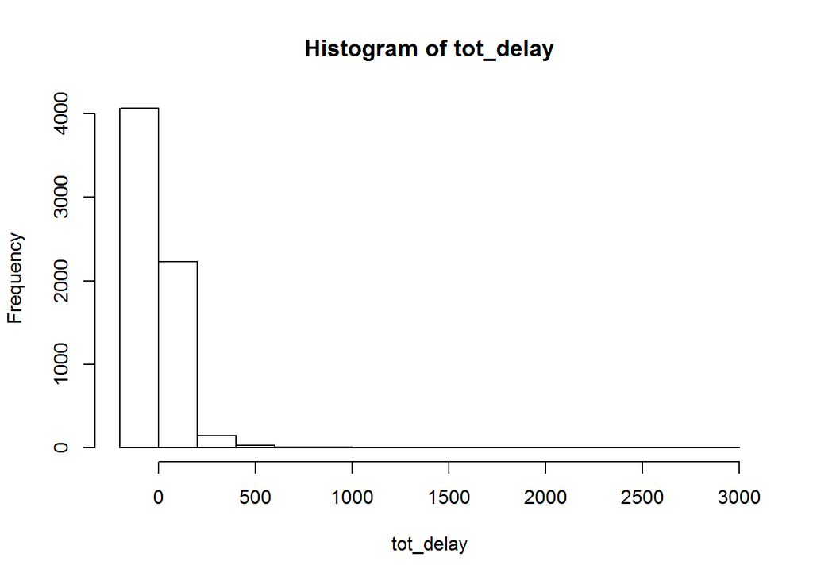

```r
with( DFW, hist( tot_delay ) )
```

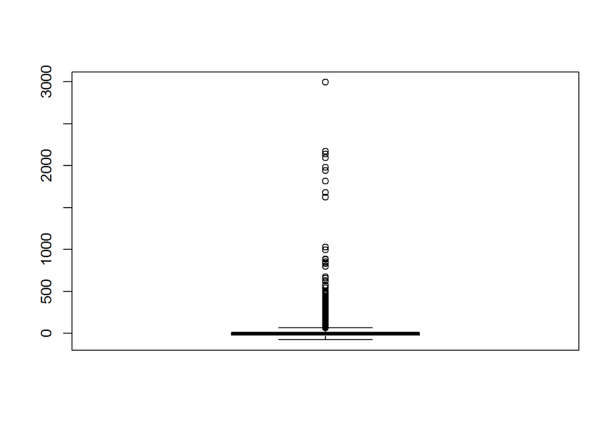

```r
with( DFW, boxplot( tot_delay ) )
```

```r
with( DFW, summary( tot_delay ) )
```

```
##    Min. 1st Qu.  Median    Mean 3rd Qu.    Max.
##  -76.00  -22.00   -8.00   13.99   14.00 2992.00
```